# Problem Set 4 - Part C

```
## Package version: 1.3.14
```

```
## Parallel computing: 2 of 4 threads used.
```

```
## See https://quanteda.io for tutorials and examples.
```

### Topic models

1. The running example in this exercise will focus on understanding the communication strategies of Donald Trump on Twitter. First, read the file `trump-tweets.csv`, which contains Trump’s tweets from January 1st 2017 to June 29th 2018. Create a histogram with the number of tweets by month.

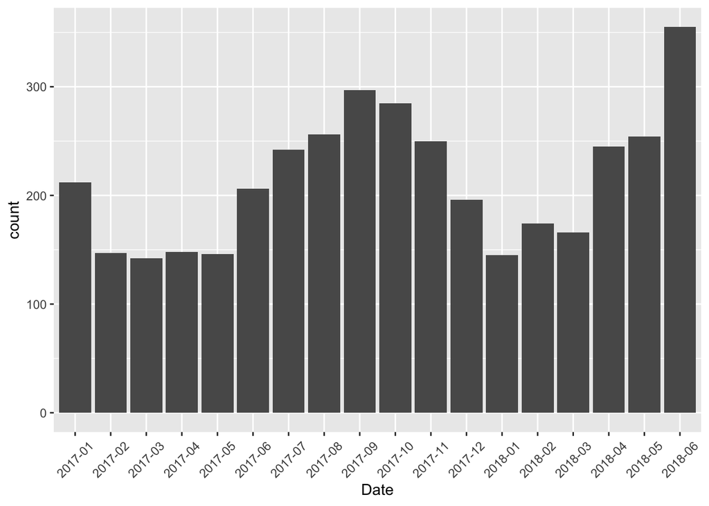

```r
library(ggplot2)
tweets <- readr::read_csv("trump-tweets.csv", col_types="cTDc")
tweets$date <- format(tweets$date, "%Y-%m")

ggplot(tweets, aes(x=tweets$date)) +
geom_histogram(stat="count", )+
scale_x_discrete("Date")+
theme(axis.text.x = element_text(angle = 45, hjust = 0.5, vjust = 0.5))
```

Create a corpus object and a DFM using options that seem appropriate to you.

```r
library(quanteda)
#Create a corpus object a DFM:
tweetc <- corpus(tweets$text)

#Create a DFM:
dfmt <- dfm(tweetc, remove=stopwords("english"), remove_url=TRUE, remove_punct=TRUE,
             stem = TRUE, verbose=TRUE)
```

```
## Creating a dfm from a corpus input...
```

```
##    ... lowercasing
```

```
##    ... found 3,866 documents, 8,456 features
```

```
##    ... removed 158 features
##    ... stemming features (English)
## , trimmed 2093 feature variants
##    ... created a 3,866 x 6,205 sparse dfm
##    ... complete.
## Elapsed time: 0.246 seconds.
```

```r
dfmt <- dfm_trim(dfmt, min_docfreq = 2, verbose = TRUE)
```

```
## Removing features occurring:
##   - in fewer than 2 documents: 2,819
##   Total features removed: 2,819 (45.4%).
```

```r
tweets <- tweets[-which(rowSums(dfmt) == 0), ]
dfmt <- dfmt[-which(rowSums(dfmt) == 0)]
```

2. Run an LDA model. You may want to experiment with different number of topics or just stick to `K=30` as in the previous example, and to experiment with different pre-processing decisions.

```r
#install.packages("topicmodels")
library(topicmodels)
K <- 10
lda <- LDA(dfmt, k = K, method = "Gibbs",
                control = list(verbose=25L, seed = 123, burnin = 100, iter = 500))
```

[output not shown]

Look at the words most asociated with each topic for a sample of topics. Do you find that the results are valid according to the different definitions of validity we discussed in the lecture? Can you put labels to the topics?

```r
terms <- get_terms(lda, 15)
terms[,1]
```

```
##  [1] "look"    "meet"    "good"    "korea"   "north"   "see"     "happen"
##  [8] "world"   "forward" "watch"   "talk"    "head"    "also"    "made"
## [15] "leader"
```

```r
topics <- get_topics(lda, 1)
head(topics)
```

```
## text1 text2 text3 text4 text5 text6
##     2     6     1     4     9     6
```

```r
# Topic 1
paste(terms[,1], collapse=", ")
```

```
## [1] "look, meet, good, korea, north, see, happen, world, forward, watch, talk, head, also, made, leader"
```

```r
sample(tweets$text[topics==1], 1)
```

```
## [1] "Going to the White House is considered a great honor for a championship team.Stephen Curry is hesitating,therefore invitation is withdrawn!"
```

```r
#North Korea issue
# Topic 9
paste(terms[,9], collapse=", ")
```

```
## [1] "news, fake, media, russia, report, fbi, total, campaign, stori, clinton, hillari, comey, russian, witch, collus"
```

```r
sample(tweets$text[topics==9], 1)
```

```
## [1] "Secret Service has just informed me that Senator Jon Tester’s statements on Admiral Jackson are not true. There were no such findings. A horrible thing that we in D.C. must live with, just like phony Russian Collusion. Tester should lose race in Montana. Very dishonest and sick!"
```

```r
#Response to the suspect of the Russia-Trump ties
paste(terms[,6], collapse=", ")
```

```
## [1] "big, get, great, republican, vote, senat, hous, go, win, dem, even, support, bill, love, last"
```

```r
sample(tweets$text[topics==6], 1)
```

```
## [1] "RT @realDonaldTrump: We grieve for the terrible loss of life, and send our support and love to everyone affected by this horrible attack in…"
```

```r
#Support Republican campaign
```

**I think the results are quite valid. According to semantic validity, the words in the same group are related to a same topic. According to construct validity, the topics are what I knew that Trump talked frequently. The predictive validity is also good as it can capture the related revents well, and I will show it on the question 3.**

3. Pick a topic whose prevalence you think may have evolved over time and plot it. (For example, North Korea). What do you find?

```r
# Topic 1
paste(terms[,1], collapse=", ")
```

```
## [1] "look, meet, good, korea, north, see, happen, world, forward, watch, talk, head, also, made, leader"
```

```r
sample(tweets$text[topics==1], 1)
```

```
## [1] "Great to be in Riyadh, Saudi Arabia. Looking forward to the afternoon and evening ahead. #POTUSAbroad https://t.co/JJOra0KfyR"
```

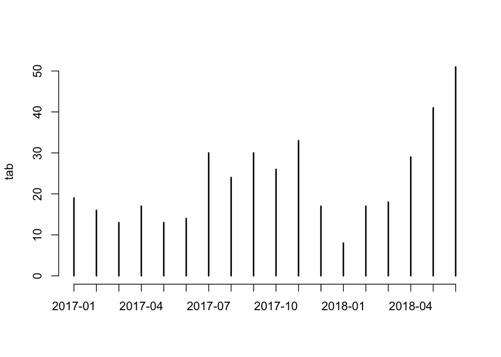

```r
# add predicted topic to dataset
tweets$pred_topic <- topics
#tweets$year <- substr(nyt$datetime, 1, 4) # extract year
 # frequency table with articles about stock market, per year
tab <- table(tweets$date[tweets$pred_topic==1])
plot(tab)
```

**The plot of “North Korea” topic over time can capture the correct spotlights (and Trump’s attention) to this topic, so the predictive validity is good. On April 5th, North Korea’s test-firing of a medium-range ballistic missile started the tension, which drew attention from Trump. On July 4th North Korea conducted the first publicly announced flight test of its ICBM Hwasong-14, again drew spotlights. On September 3, North Korea had conducted a sixth nuclear weapon test. In April 2018, Trump announced and talked about meeting Kim Jong-un, then both Moon and Kim signed the Panmunjom Declaration, declaring the Korean conflict over, which made Trump tweet a lot. Then in June 2018, Singapore summit made US and North Korean meet the first time after Korean War, which is a historic moment of “North Korea” issue.**

4. For this topic, compute the probabilities that each word is associated with the topic. You should be able to get them from the `beta` value within the `LDA` object. Note that the values of this matrix are in the log scale; in order to get the probabilities you’ll need to exponentiate them. Sort the words from highest to lowest probability and display the top 30. If your code is correct, you should see the same result as when you ran `terms()` earlier:

```r
lda@terms[order(exp(lda@beta[1,]), decreasing = T)][1:30]
```

```
##  [1] "look"    "meet"    "good"    "korea"   "north"   "see"     "happen"
##  [8] "world"   "forward" "watch"   "talk"    "head"    "also"    "made"
## [15] "leader"  "final"   "now"     "believ"  "hope"    "great"   "repres"
## [22] "south"   "place"   "problem" "truli"   "play"    "iran"    "import"
## [29] "peac"    "respect"
```

5. Now, use this metric but to extract the probability that a given word belongs to each of the topics. Choose the word “russia” (or any other word you find relevant) and compute those probabilities. Note that these probabilities will probably be very small, but you can normalize them so that they all up to one for this given word. To which topic does the word “Russia” belong?

```r
#lda@terms[order(exp(lda@beta[1,]), decreasing = T)]
exp(lda@beta[1,])[which(lda@terms == "russia")]
```

```
## [1] 0.0005832988
```

```r
probdf <- data.frame("topic"=c(1:10), "prob"=c(1:10))
for (i in 1:10){
  probdf$prob[i] <-exp(lda@beta[i,])[which(lda@terms == "russia")]
  probdf$prob <- (probdf$prob-min(probdf$prob))/(max(probdf$prob)-min(probdf$prob))
}
probdf[which.max(probdf$prob),]
```

```
##   topic prob
## 9     9    1
```

```r
paste(terms[,9], collapse=", ")
```

```
## [1] "news, fake, media, russia, report, fbi, total, campaign, stori, clinton, hillari, comey, russian, witch, collus"
```

```r
sample(tweets$text[topics==9], 5)
```

```
## [1] "The failing @nytimes does major FAKE NEWS China story saying \"Mr.Xi has not spoken to Mr. Trump since Nov.14.\" We spoke at length yesterday!"
## [2] "RT @foxandfriends: .@jasoninthehouse: Anything Mueller is doing with his investigation is tainted by the anti-Trump FBI agents https://t.co…"
## [3] "I have a great relationship with Angela Merkel of Germany, but the Fake News Media only shows the bad photos (implying anger) of negotiating an agreement - where I am asking for things that no other American President would ask for! https://t.co/Ib97nN5HZt"
## [4] "We should start an immediate investigation into @SenSchumer and his ties to Russia and Putin. A total hypocrite! https://t.co/Ik3yqjHzsA"
## [5] "The true question for the @UN...\n\U0001f3a5https://t.co/tx5SnACAaS"
```

**“Russia” belongs to the topic 9, which is a topic about response to the suspect of the Russia-Trump ties’**